# Flights through the ependamic

With Qantas Airways

Jelly Dongyi Guo - 470033070

University of Sydney | MATH1115 | October 2021

# 1 Introduction

## 1.1 Background

There is definitely a huge impact on global airline industry because of the COVID-19 pandemic, especially for those who carries lots of international airlines: simply because of COVID-19, there were 75% of the domestic flight trips and 93% of the international ones canceled or suspended(OliverWyman, 2021). For United States, the capacity of available seat miles decreased even more rapid than 9/11 terror attacks and Global Economic Crisis, plus the H1N1 pandemic, which for those events the capacity stayed over 80% but below 40% for COVID-19 during at least 9 months after events broke out(OliverWyman, 2021). The International Air Transport Association even made the prediction that there would be no cash-positive for the whole aviation industry in globe, where the expected losses to November is US$38.7 billion in 2021, after losing US$118.5 billion in 2020 (OliverWyman, 2021).

Unfortunately, Australia is not escaped. In the sole year of 2020, the whole Oceania lost 65.6% of available seat miles capacity of all flight services and 56.8% on domestic lines compared to 2019, which is the most decreased capacity in available seat miles among all regions(OliverWyman, 2021).

## 1.2 Stakeholder

My stakeholder, Qantas Airways, founded in 1920, nicknamed “The Flying Kangaroo”, is the biggest airline company in Southern Hemisphere and 3rd most historic airline company around the world. It has also been often nominated as the safest airline company as it is recorded having no fatal accidents since 1951.

However, COVID-19 does not take a break of damaging for anyone, Qantas has predicted that the pandemic would likely to cause a AU$20 billion loss on revenue at the end of 2021(BBC, 2021), pushing it to plan axing around 6000 jobs, after putting two thirds of the employees on leave on March 2020.

Though the speedy vaccination rolling out quickly, steps become further to get on the track before the breakout, the airline companies are still predicted to compete with each other in such limited and narrow situations for a while as the border is still closed for foreigners and there is still continuous effort on combating with the COVID-19(OliverWyman, 2021).

# 2 Executive Summary

The report aims to study on past flight data and identify possible relationships between categories or some facts which could hint my stakeholder to narrow down financial losses in some ways. Our recommendations in the end are bit subtle: it is quite important to stay with our frequent flyers, especially for those who came from our most frequently flying region - New Zealand instead of trying to break through from other perspectives due to the fact that in this report’s study the future is not that predictable and those who brings lots of flying opportunities - which brings customers and revenues - are not sharing much common spots than the others.

# 3 Initial Data Analysis (IDA)

This data was collected by the Bureau of Infrastructure and Transport Research Economics from third parties, although the accuracy, reliability and fitness for any purpose of this dataset are promised, as one of the Commonwealths, the credibility of this gathered data is still up high especially there is no harm for any party involved to submit the data excepted accidentally breaking some entries.

```r
# Prepare Data
read_csv("data/data.csv", name_repair = janitor::make_clean_names) %>%
  filter(airline == "Qantas Airways") %>%
  select(-month, -in_out, -australian_city, -international_city, -port_country, -service_country, -service_region, -airline, -route, -stops) -> data
```

# 4 Data Analysis and Recommendations

During such a tough period of time, the most obvious way of preserving from losses and still competing in the flight business game is to spend the cents on the key services that are highly demanded, especially those who potentially can gain the fastest financial recovery.

[output not shown]

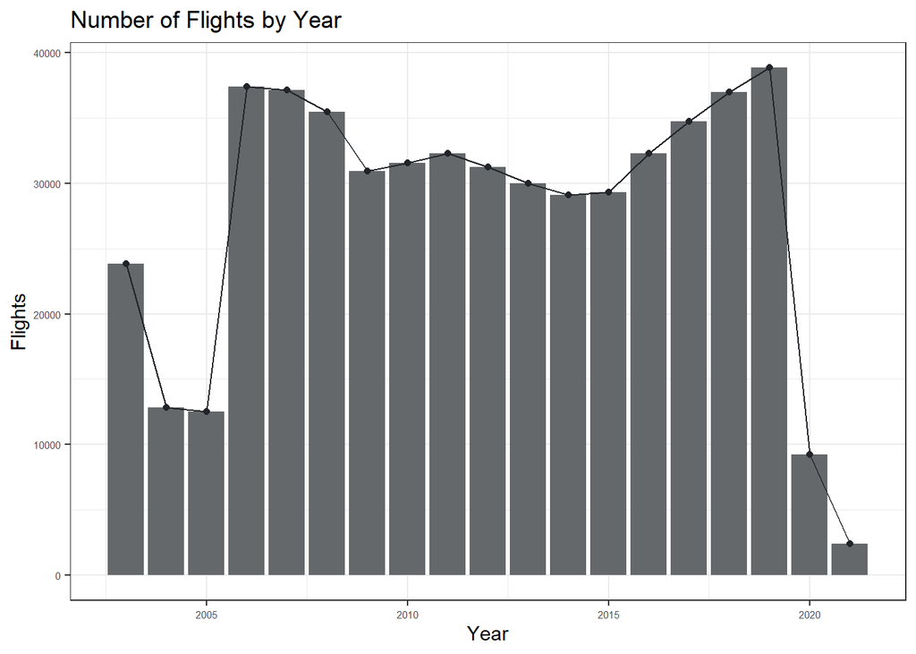

```r
data %>%
  select(year, all_flights,max_seats) %>%
  plyr::ddply("year", plyr::numcolwise(sum)) %>%
  mutate(
   all_flights = case_when(
      year == 2003 ~ all_flights*4,
      year == 2021 ~ all_flights*2,
      TRUE ~ as.numeric(all_flights)
    )
  ) %>%
  mutate(
   max_seats = case_when(
      year == 2003 ~ max_seats*4,
      year == 2021 ~ max_seats*2,
      TRUE ~ as.numeric(max_seats)
    )
  ) -> table_of_years

mean_flights <- trunc(mean(table_of_years$all_flights), digits = 0)
mean_max_seats <- trunc(mean(table_of_years$max_seats), digits = 0)

table_of_years %>%
  filter(year == 2020) %>%
  select(all_flights) -> flights_2020
table_of_years %>%
  filter(year == 2021) %>%
  select(all_flights) -> flights_2021
table_of_years %>%
  filter(year == 2020) %>%
  select(max_seats) -> max_seats_2020
table_of_years %>%
  filter(year == 2021)%>%
  select(max_seats)  -> max_seats_2021

table_of_years %>%
  ggplot(aes(x = year, y = all_flights)) +
  geom_bar(stat = "identity") +
  geom_point() +
  geom_line() +
  ggtitle("Number of Flights by Year") +
  xlab("Year") +
  ylab("Flights") +
  theme_bw() +
  geom_blank()
```

[output not shown]

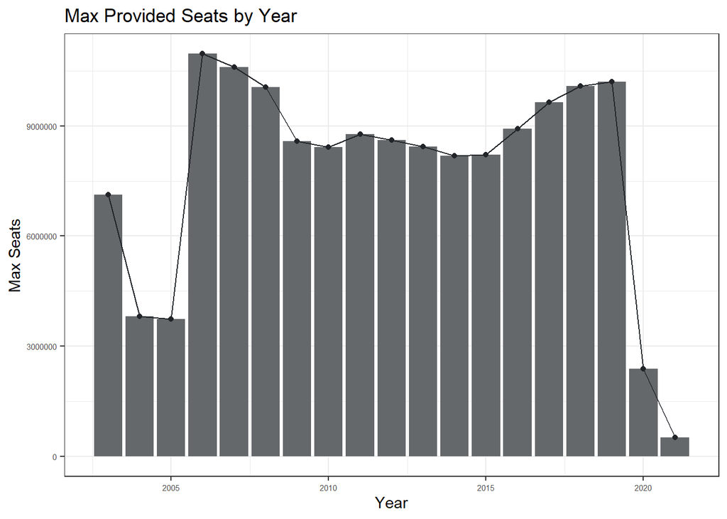

```r
table_of_years %>%
  ggplot(aes(year, max_seats)) +
  geom_bar(stat = "identity") +
  geom_point() +
  geom_line() +
  ggtitle("Max Provided Seats by Year") +
  xlab("Year") +
  ylab("Max Seats") +
  theme_bw() +
  geom_blank()
```

It is quite significant the impact of COVID-19 hit hard on possible journey during its period of time. In 2020, there were only 9260 Qantas Airways flights made a trip with total 2385793 seats, and things get worse in 2021, only 2432 flights took part with 519784 capacity of seats, where from 2003 to 2021, averagely there are 27794 flights per year with 7751101 seats capacity.

A temporary heads-down is not worrying, but a long-term trend is. Is the appearances of each provided services and seats capacities falling down before the pandemic or it was actually rising up but just got pinned down by COVID-19? Or equally saying:

## 4.1 Linear Model

> **Is there a linear model between the flight services appearances and the year before 2020 COVID-19 breakout? How about the capacity of seats and the year?**

```r
data %>%
  filter(year < 2020) %>%
  ggplot(aes(year, all_flights)) +
  geom_point() +
  geom_smooth(aes(colour = "Linear Model"), method = "lm", fill = "blue", alpha = .05) +
  geom_smooth(aes(colour = "LOESS"), fill = "pink", alpha = .05) +
  scale_colour_manual(name = "", values = c("blue", "pink")) +
  theme_bw() +
  theme(legend.position = "bottom") +
  ggtitle("Flight Services Appearances by Year") +
  xlab("Year") +
  ylab("Flights") +
  geom_blank() -> plot_flights

data %>%
  filter(year < 2020) %>%
  ggplot(aes(year, max_seats)) +
  geom_point() +
  geom_smooth(aes(colour = "Linear Model"), method = "lm", fill = "blue", alpha = 1) +
  geom_smooth(aes(colour = "LOESS"), fill = "pink", alpha = 1) +
  scale_colour_manual(name = "", values = c("blue", "pink")) +
  theme_bw() +
  theme(legend.position = "bottom") +
  ggtitle("Max Seats Capacities by Year") +
  xlab("Year") +
  ylab("Max Seats") +
  geom_blank() -> plot_seats

fit_flights <- lm(all_flights ~ year, data = data %>% filter(year < 2020))
fit_seats <- lm(max_seats ~ year, data = data %>% filter(year < 2020))
fit_flights_poly <- lm(all_flights ~ poly(year,2), data = data)
fit_seats_ploy <- lm(max_seats ~ poly(year,2), data = data)
```

In order to find the linear model, scatter plots can be helpful:

[output not shown]

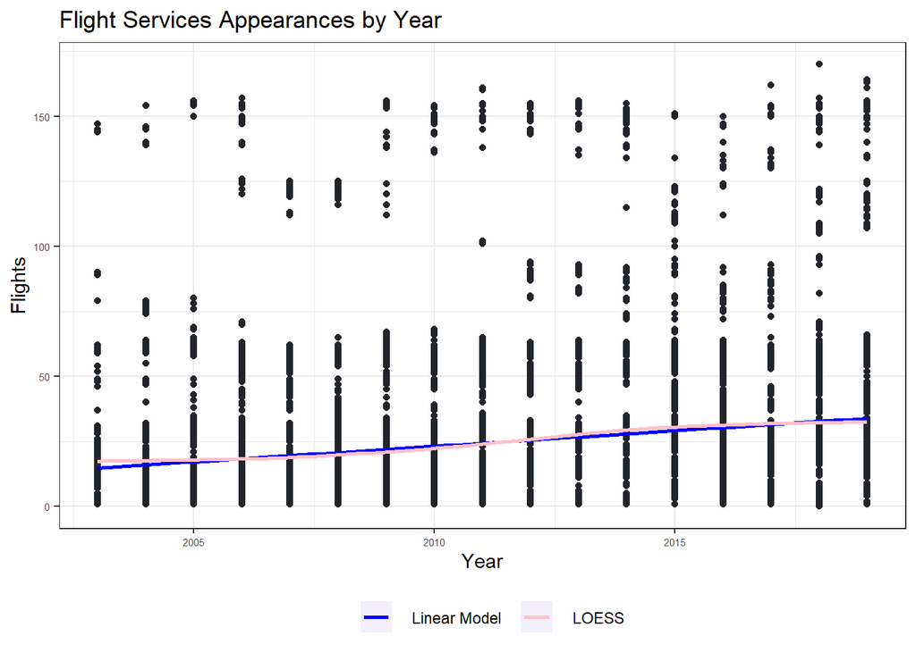

```r
plot_flights
```

[output not shown]

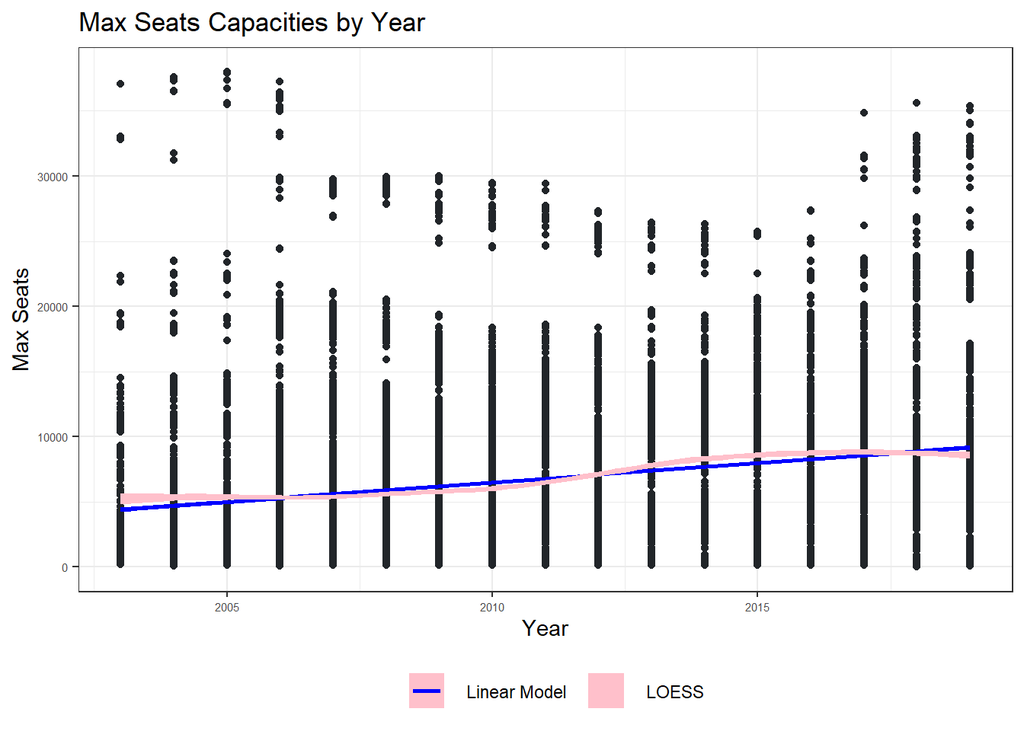

```r
plot_seats
```

Although the linear model and the LOESS are really close to each other because of the massiveness of data on the plot, it is quite unlikely that linear model is the case here since LOESS fluctuates around the linear model line multiple times. However, to confirm on this, there are further investigation:

[output not shown]

[output not shown]

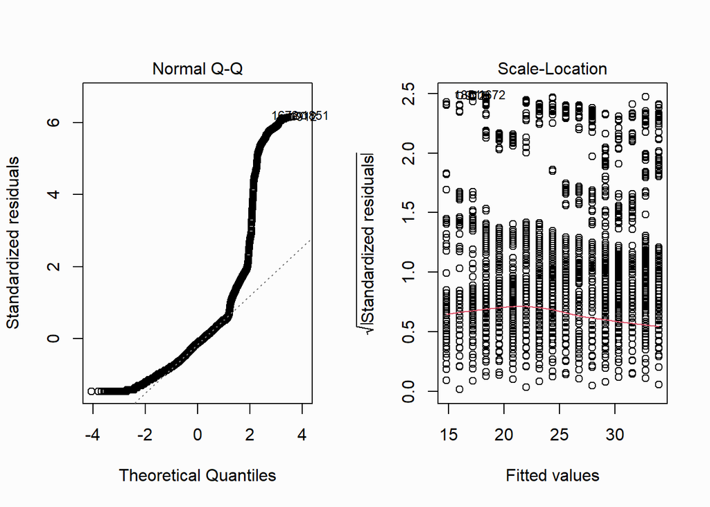

```r
par(mfrow = c(1,2))
plot(fit_flights, which = 2:3)
```

[output not shown]

[output not shown]

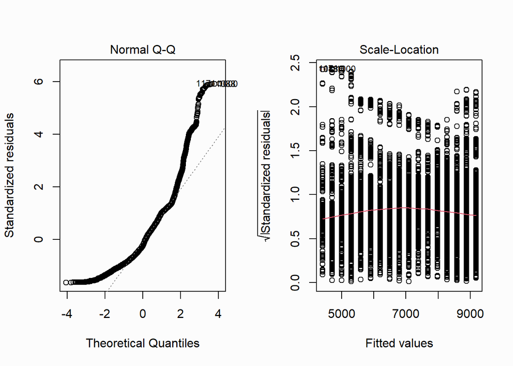

```r
plot(fit_seats, which = 2:3)
```

```r
summary(fit_flights)
```

```
##
## Call:
## lm(formula = all_flights ~ year, data = data %>% filter(year <
##     2020))
##
## Residuals:
##     Min      1Q  Median      3Q     Max
## -32.920 -13.748  -2.920   6.642 138.814
##
## Coefficients:
##                Estimate  Std. Error t value            Pr(>|t|)
## (Intercept) -2379.37651    69.96323  -34.01 <0.0000000000000002 ***
## year            1.19529     0.03479   34.36 <0.0000000000000002 ***
## ---
## Signif. codes:  0 '***' 0.001 '**' 0.01 '*' 0.05 '.' 0.1 ' ' 1
##
## Residual standard error: 22.43 on 20485 degrees of freedom
## Multiple R-squared:  0.05448,    Adjusted R-squared:  0.05444
## F-statistic:  1180 on 1 and 20485 DF,  p-value: < 0.00000000000000022
```

```r
summary(fit_seats)
```

```
##
## Call:
## lm(formula = max_seats ~ year, data = data %>% filter(year <
##     2020))
##
## Residuals:
##    Min     1Q Median     3Q    Max
##  -9104  -4197  -1298   3280  32992
##
## Coefficients:
##                Estimate  Std. Error t value            Pr(>|t|)
## (Intercept) -593125.999   17357.612  -34.17 <0.0000000000000002 ***
## year            298.318       8.631   34.56 <0.0000000000000002 ***
## ---
## Signif. codes:  0 '***' 0.001 '**' 0.01 '*' 0.05 '.' 0.1 ' ' 1
##
## Residual standard error: 5564 on 20485 degrees of freedom
## Multiple R-squared:  0.0551, Adjusted R-squared:  0.05505
## F-statistic:  1195 on 1 and 20485 DF,  p-value: < 0.00000000000000022
```

The theory is also confirmed by doing the linear model summary where R-squared value is insufficient (while R-squared values are all around 0.055 with P-values extremely close to 0), this is not changing even a polynomial fitting is applied (as code chunk below, R-squared values goes around 0.04 and literally 0 P-values), which leads to the conclusion that there is no linear model between how many services or capacities of seats and the year.

```r
summary(fit_flights_poly)
```

```
##
## Call:
## lm(formula = all_flights ~ poly(year, 2), data = data)
##
## Residuals:
##     Min      1Q  Median      3Q     Max
## -31.642 -13.828  -1.987   6.277 139.084
##
## Coefficients:
##                Estimate Std. Error t value             Pr(>|t|)
## (Intercept)     24.3147     0.1554 156.473 < 0.0000000000000002 ***
## poly(year, 2)1 731.9903    22.4830  32.557 < 0.0000000000000002 ***
## poly(year, 2)2 -80.8393    22.4830  -3.596             0.000324 ***
## ---
## Signif. codes:  0 '***' 0.001 '**' 0.01 '*' 0.05 '.' 0.1 ' ' 1
##
## Residual standard error: 22.48 on 20931 degrees of freedom
## Multiple R-squared:  0.04876,    Adjusted R-squared:  0.04867
## F-statistic: 536.5 on 2 and 20931 DF,  p-value: < 0.00000000000000022
```

```r
summary(fit_seats_ploy)
```

```
##
## Call:
## lm(formula = max_seats ~ poly(year, 2), data = data)
##
## Residuals:
##    Min     1Q Median     3Q    Max
##  -8702  -4214  -1262   3231  33052
##
## Coefficients:
##                 Estimate Std. Error t value             Pr(>|t|)
## (Intercept)      6767.07      38.61 175.276 < 0.0000000000000002 ***
## poly(year, 2)1 178770.56    5586.06  32.003 < 0.0000000000000002 ***
## poly(year, 2)2 -21914.40    5586.06  -3.923            0.0000877 ***
## ---
## Signif. codes:  0 '***' 0.001 '**' 0.01 '*' 0.05 '.' 0.1 ' ' 1
##
## Residual standard error: 5586 on 20931 degrees of freedom
## Multiple R-squared:  0.04732,    Adjusted R-squared:  0.04723
## F-statistic: 519.8 on 2 and 20931 DF,  p-value: < 0.00000000000000022
```

## 4.2 Chi-square Test (Goodness of Fit)

> **What is the month which is most traveled in? What is the most frequently traveled region? Is the “intense” of the months from the most frequently traveled region really differing from the others?**

Firstly, we locate the month and the continent, for this time, since the data from 2003 and 2021 is not a whole-year record, they will be excepted in this investigation:

[output not shown]

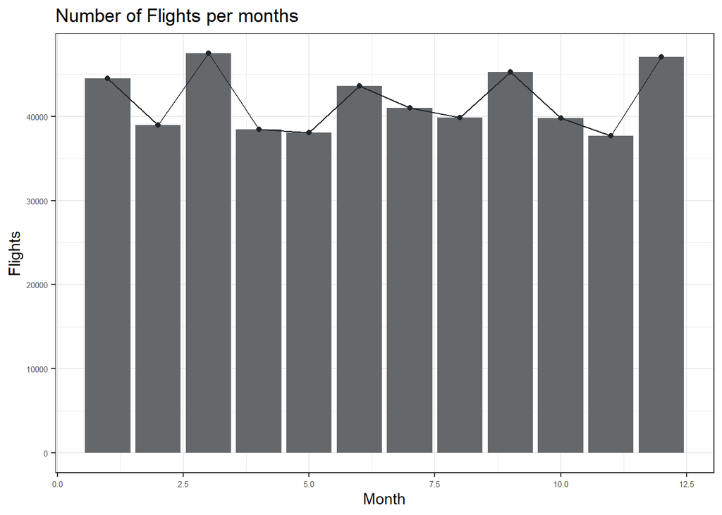

```r
data %>%
  filter(year != 2021) %>%
  filter(year != 2003) %>%
  select(month_num, all_flights,max_seats) %>%
  plyr::ddply("month_num", plyr::numcolwise(sum)) -> table_of_months

table_of_months %>%
  ggplot(aes(x = month_num, y = all_flights)) +
  geom_bar(stat = "identity") +
  geom_point() +
  geom_line() +
  ggtitle("Number of Flights per months") +
  xlab("Month") +
  ylab("Flights") +
  theme_bw() +
  geom_blank()
```

[output not shown]

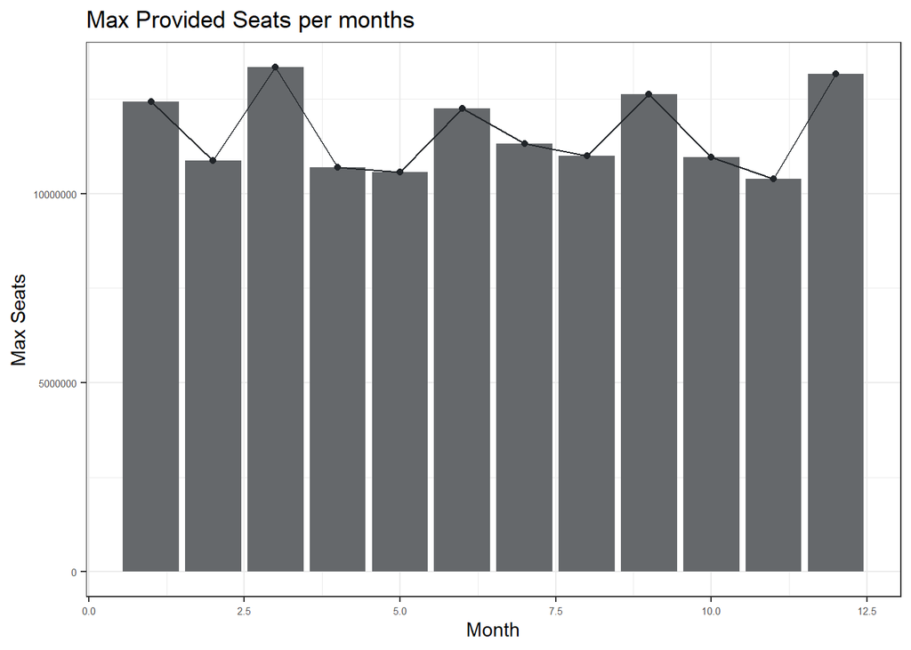

```r
table_of_months %>%
  ggplot(aes(x = month_num, y = max_seats)) +
  geom_bar(stat = "identity") +
  geom_point() +
  geom_line() +
  ggtitle("Max Provided Seats per months") +
  xlab("Month") +
  ylab("Max Seats") +
  theme_bw() +
  geom_blank()
```

For the month it is quite obvious that March and December are more outstanding than others, but March wins slightly based on the comparing below:

```r
table_of_months %>% filter(month_num == 3) %>% select(all_flights) > table_of_months %>% filter(month_num == 12) %>% select(all_flights)
```

```
##      all_flights
## [1,]        TRUE
```

```r
table_of_months %>% filter(month_num == 3) %>% select(max_seats) > table_of_months %>% filter(month_num == 12) %>% select(max_seats)
```

```
##      max_seats
## [1,]      TRUE
```

Looking into the most frequently traveled region:

[output not shown]

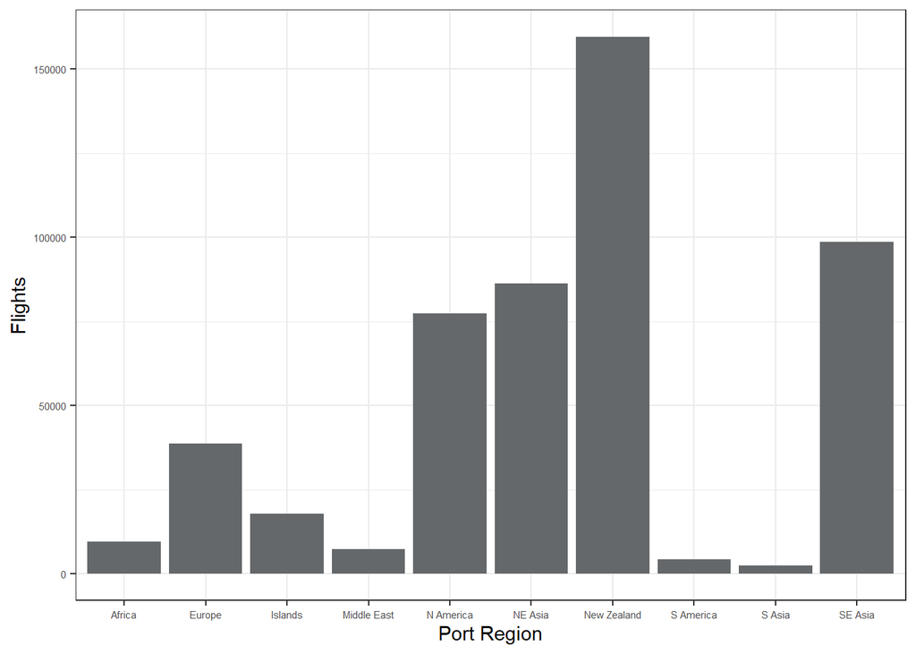

```r
data %>%
  filter(year != 2021) %>%
  filter(year != 2003) %>%
  select(port_region, all_flights,max_seats) %>%
  plyr::ddply("port_region", plyr::numcolwise(sum)) -> table_of_region

table_of_region %>%
  ggplot(aes(x = port_region, y = all_flights)) +
  geom_bar(stat = "identity") +
  xlab("Port Region") +
  ylab("Flights") +
  theme_bw() +
  geom_blank()
```

[output not shown]

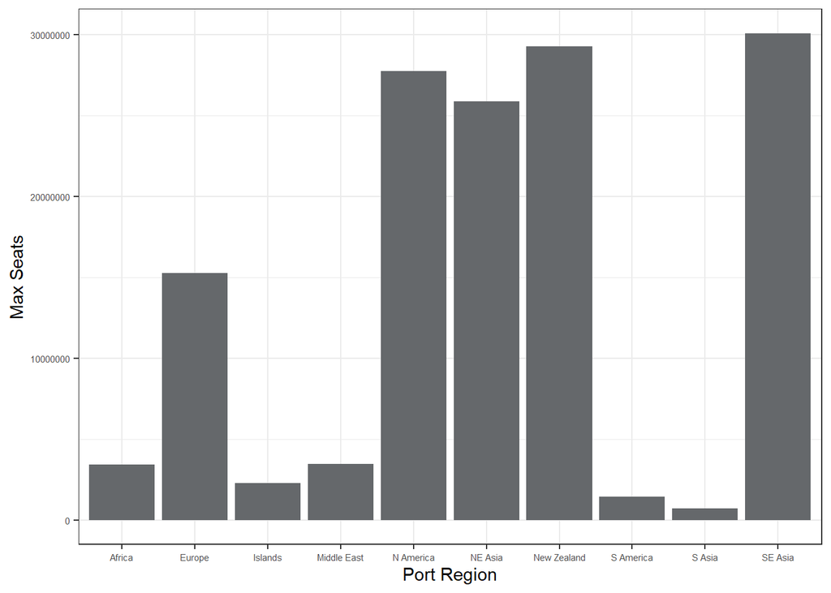

```r
table_of_region %>%
  ggplot(aes(x = port_region, y = max_seats)) +
  geom_bar(stat = "identity") +
  xlab("Port Region") +
  ylab("Max Seats") +
  theme_bw() +
  geom_blank()
```

From the plot we can see although SE Asia tends to be provided with slightly more seat capacities among trips from or to Australia, the New Zealand is definitely still the most frequent travel departure or destination that Australia is having with much more flights communicating between Australia and New Zealand.

Now the question becomes:

> **Is there a region disparity in the proportion of most frequently traveled months?**

And in order to solve this, a chi-square test can be super helpful. Firstly, hypothesizes are pulled up:

- $H_0$ (Null Hypothesis): The flights per month are distributed in the same ratio as the general flight’s monthly distribution.
- $H_1$ (Alternative Hypothesis): The flights per month are **NOT** distributed in the same ratio as the general flight’s monthly distribution.

```r
# Total flights
flight_sum <- sum(table_of_months$all_flights)

# Get EV
table_of_months %>%
  select(all_flights) %>%
  mutate(all_flights = all_flights / flight_sum) %>%
  pull(all_flights) -> expected

# Get New Zealand's all flights by months
data %>%
  filter(port_region == "New Zealand") %>%
  select(month_num, all_flights) %>%
  plyr::ddply("month_num", plyr::numcolwise(sum)) %>%
  as.tibble() -> flights_by_months_nz

observed <- flights_by_months_nz$all_flights
```

Assumptions are checked below based on the observed and expected possibility calculated above since the data are quite independently collected (third-parties):

```r
sum(observed) * expected
```

```
##  [1] 14437.70 12656.16 15418.87 12487.06 12348.79 14164.09 13310.48 12938.85
##  [9] 14686.00 12914.19 12240.06 15274.76
```

```r
chi_test <- chisq.test(observed, p = expected)
chi_test
```

```
##
##  Chi-squared test for given probabilities
##
## data:  observed
## X-squared = 112.42, df = 11, p-value < 0.00000000000000022
```

Here the test statistics are revealed here as 112.4176793 and the P-value 0 is way smaller than 0.01 even at a 5% level of confidence. Thus, the null hypothesis is rejected here, and New Zealand’s monthly flight performances is not distributed like the performances overall, it is impossible to just copy the heat map of traveling month from the general distribution and paste on Qantas’ most frequently traveled region.

# 5 References

- BBC, August 26, 2021, Covid: Qantas says pandemic to cost billions in lost revenue, Retrieved from: https://www.bbc.com/news/business-58338262 [Access Date: 17/10/2021]
- OliverWyman, 2021, Airline Economic Analysis 2020-2021, Retrieved from: https://www.oliverwyman.com/our-expertise/insights/2021/mar/airline-economic-analysis-2020-2021.html [Access Date: 17/10/2021]